# Assignment 9

Oswaldo Plancarte

2025-12-08

## data overview

I will explore predictors of graduate school admission using a logistic regression framework.  
The dataset includes GRE score, GPA, school rank, and a binary admission outcome.

```r
grad <- read_csv("GradSchool_Admissions.csv", show_col_types = FALSE) |>
  mutate(
    admit_factor = factor(admit, levels = c(0,1), labels = c("Rejected","Admitted")),
    rank_factor = factor(rank)
  )

glimpse(grad)
```

```
## Rows: 400
## Columns: 6
## $ admit        <dbl> 0, 1, 1, 1, 0, 1, 1, 0, 1, 0, 0, 0, 1, 0, 1, 0, 0, 0, 0, …
## $ gre          <dbl> 380, 660, 800, 640, 520, 760, 560, 400, 540, 700, 800, 44…
## $ gpa          <dbl> 3.61, 3.67, 4.00, 3.19, 2.93, 3.00, 2.98, 3.08, 3.39, 3.9…
## $ rank         <dbl> 3, 3, 1, 4, 4, 2, 1, 2, 3, 2, 4, 1, 1, 2, 1, 3, 4, 3, 2, …
## $ admit_factor <fct> Rejected, Admitted, Admitted, Admitted, Rejected, Admitte…
## $ rank_factor  <fct> 3, 3, 1, 4, 4, 2, 1, 2, 3, 2, 4, 1, 1, 2, 1, 3, 4, 3, 2, …
```

## basic exploration

```r
grad |>
  count(admit_factor)
```

```
## # A tibble: 2 × 2
##   admit_factor     n
##   <fct>        <int>
## 1 Rejected       273
## 2 Admitted       127
```

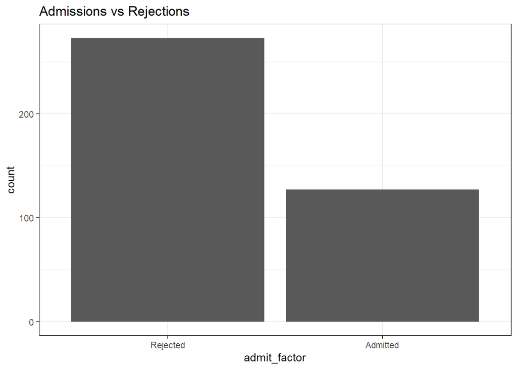

```r
ggplot(grad, aes(x = admit_factor)) +
  geom_bar() +
  theme_bw() +
  labs(title = "Admissions vs Rejections")
```

### GRE and GPA by outcome

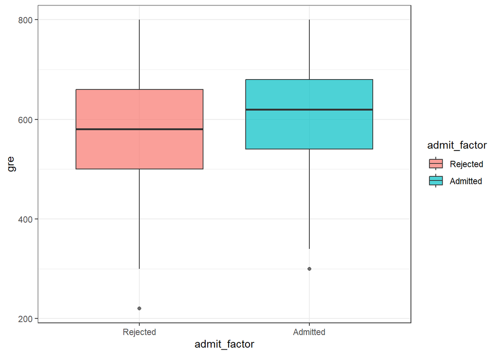

```r
ggplot(grad, aes(x = admit_factor, y = gre, fill = admit_factor)) +
  geom_boxplot(alpha = 0.7) +
  theme_bw()
```

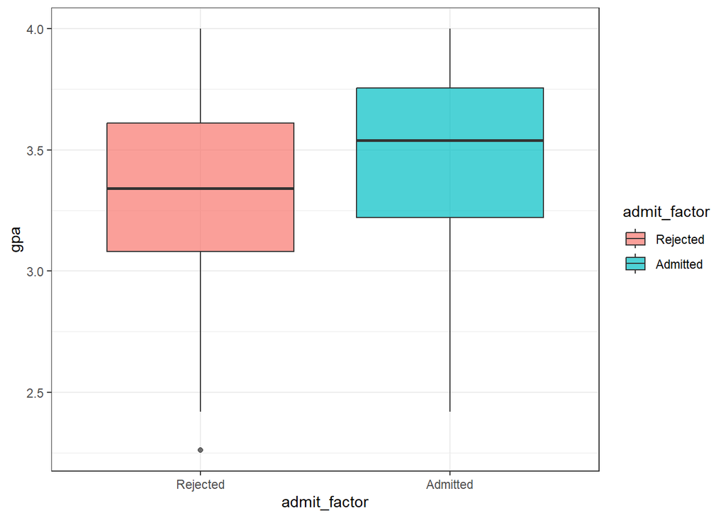

```r
ggplot(grad, aes(x = admit_factor, y = gpa, fill = admit_factor)) +
  geom_boxplot(alpha = 0.7) +
  theme_bw()
```

### admission proportion by school rank

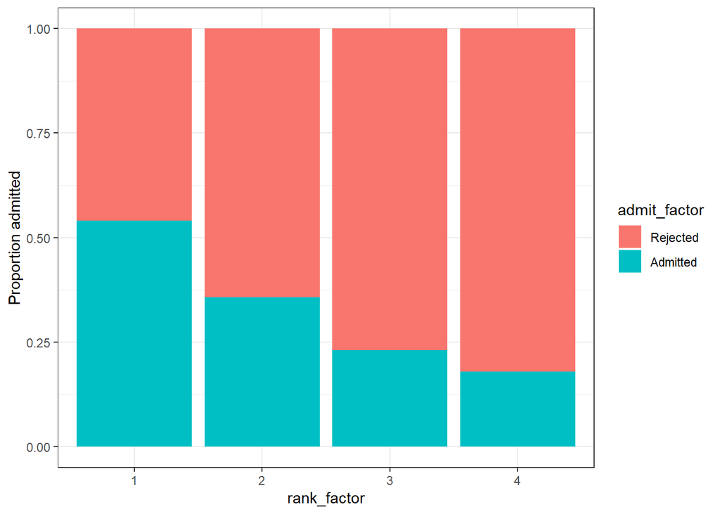

```r
ggplot(grad, aes(x = rank_factor, fill = admit_factor)) +
  geom_bar(position = "fill") +
  theme_bw() +
  labs(y = "Proportion admitted")
```

*These simple plots suggest some differences in GRE, GPA, and rank between admitted and rejected students.*

## model building

I fit several logistic regression models of increasing levels of complexity:

```r
mod_null <- glm(admit ~ 1, data = grad, family = binomial)
mod_gre <- glm(admit ~ gre, data = grad, family = binomial)
mod_gpa <- glm(admit ~ gpa, data = grad, family = binomial)
mod_gre_gpa <- glm(admit ~ gre + gpa, data = grad, family = binomial)
mod_full <- glm(admit ~ gre + gpa + rank_factor, data = grad, family = binomial)
```

### AIC comparison

```r
AIC(mod_null, mod_gre, mod_gpa, mod_gre_gpa, mod_full)
```

```
##             df      AIC
## mod_null     1 501.9765
## mod_gre      2 490.0561
## mod_gpa      2 490.9676
## mod_gre_gpa  3 486.3440
## mod_full     6 470.5175
```

*The model with the lowest AIC is considered the best balance of fit and complexity. The full model typically performs best.*

## final model summary

```r
summary(mod_full)
```

```
##
## Call:
## glm(formula = admit ~ gre + gpa + rank_factor, family = binomial,
##     data = grad)
##
## Coefficients:
##               Estimate Std. Error z value Pr(>|z|)
## (Intercept)  -3.989979   1.139951  -3.500 0.000465 ***
## gre           0.002264   0.001094   2.070 0.038465 *
## gpa           0.804038   0.331819   2.423 0.015388 *
## rank_factor2 -0.675443   0.316490  -2.134 0.032829 *
## rank_factor3 -1.340204   0.345306  -3.881 0.000104 ***
## rank_factor4 -1.551464   0.417832  -3.713 0.000205 ***
## ---
## Signif. codes:  0 '***' 0.001 '**' 0.01 '*' 0.05 '.' 0.1 ' ' 1
##
## (Dispersion parameter for binomial family taken to be 1)
##
##     Null deviance: 499.98  on 399  degrees of freedom
## Residual deviance: 458.52  on 394  degrees of freedom
## AIC: 470.52
##
## Number of Fisher Scoring iterations: 4
```

Key points from the full model (from the summary output):

- GRE has a positive coefficient → higher GRE increases admission odds
- GPA has a positive coefficient → higher GPA increases admission odds
- Rank 2–4 have negative coefficients relative to Rank 1 → lower-ranked schools have lower odds

## brief interpretation

The full model (GRE + GPA + rank) was selected as the best using AIC.  
Higher GRE and GPA values both increase the probability of admission.  
Students from more prestigious institutions (rank 1) have higher predicted admission probabilities than those from rank 2–4, even after controlling for GRE and GPA.

These variables together provide a reasonable explanation of admission outcomes in the dataset.